# Brauchle_HW8

Natascha Brauchle

April 8, 2019

```r
library(dplyr)
```

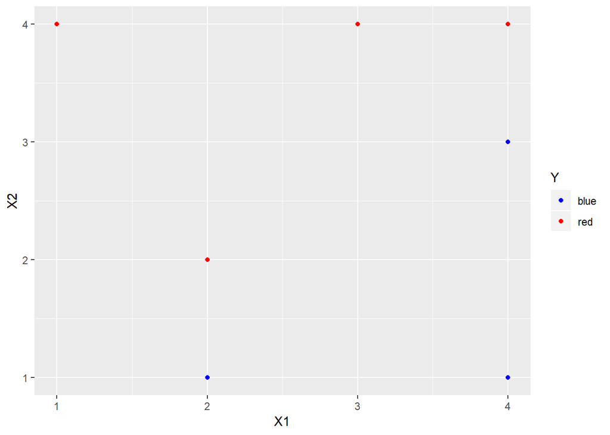

```r
library(ggplot2)
toys <- data.frame("X1" = c(3, 2, 4, 1, 2, 4, 4), "X2" = c(4, 2, 4, 4, 1, 3, 1), Y = c("red", "red", "red", "red", "blue", "blue", "blue"))
toys %>% ggplot(aes(X1, X2, color = Y)) + geom_point() + scale_color_manual(values = c("blue", "red"))
```

*3a.* This is the plot for X1 and X2 with the points colored accordingly.

*3b.* The maximal margin classifier has to be between points (2,1) and (2,2) and (4,4) and (4,3). These halfway points are (2, 1.5) and (4, 3.5). Finding the lines that pass through these points:

$$\frac{4 - 2}{3.5 - 1.5} = 1$$
and
$$1.5 - 2 = - 0.5$$
So the equation of the line is Y = -0.5 + x

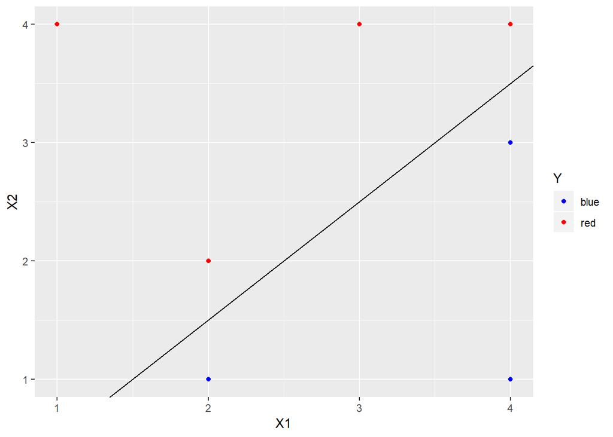

```r
toys %>% ggplot(aes(X1, X2, color = Y)) + geom_point() + scale_color_manual(values = c("blue", "red")) + geom_abline(intercept = -0.5, slope = 1)
```

*3d* Added the margins for the maxial margin hyperplane.

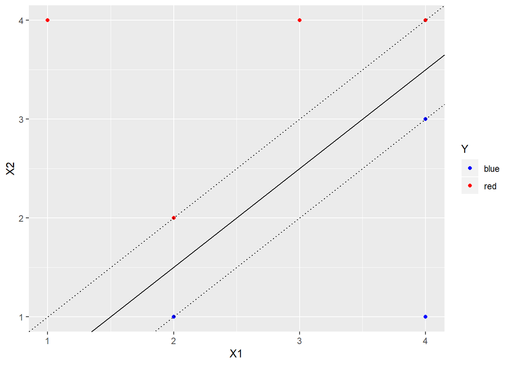

```r
toys %>% ggplot(aes(X1, X2, color = Y)) + geom_point() + scale_color_manual(values = c("blue", "red")) + geom_abline(intercept = -0.5, slope = 1) + geom_abline(intercept = -1, slope = 1, linetype = 'dotted') + geom_abline(intercept = 0, slope = 1, linetype = 'dotted')
```

```r
supports <- toys %>% filter(row_number() %in% c(1, 3, 5, 2))
supports
```

```
##   X1 X2    Y
## 1  3  4  red
## 2  2  2  red
## 3  4  4  red
## 4  2  1 blue
```

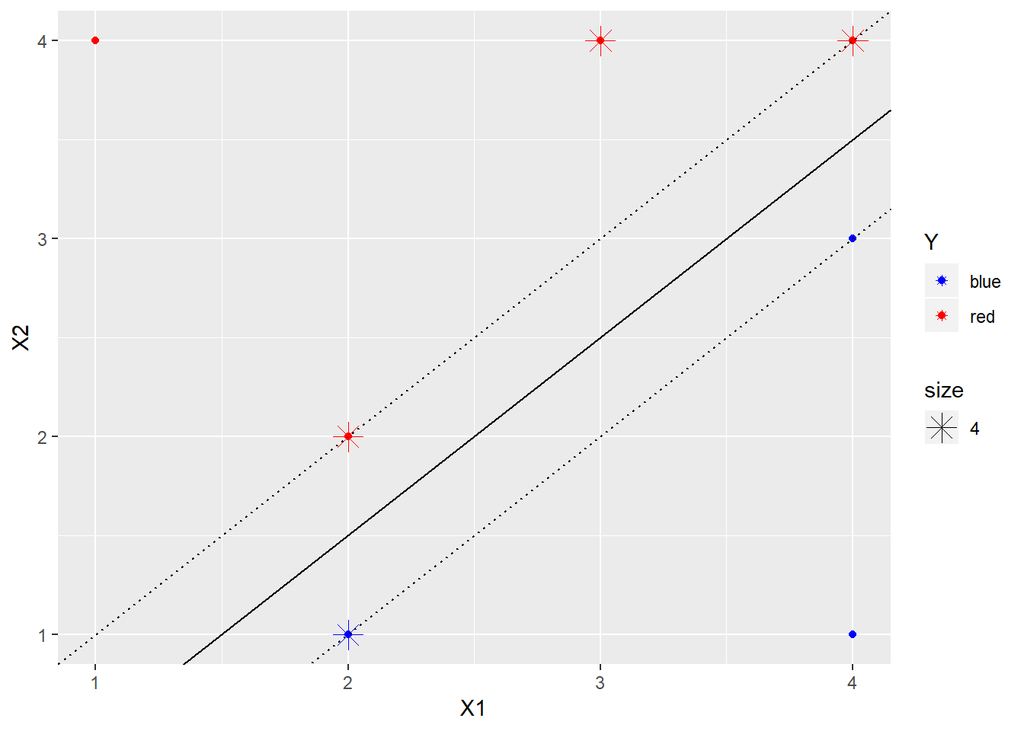

```r
  ggplot(toys, aes(X1, X2, color = Y)) + geom_point() +
  scale_color_manual(values = c("blue", "red")) +
  geom_abline(intercept = -0.5, slope = 1) +
  geom_abline(intercept = -1, slope = 1, linetype = 'dotted') +
  geom_abline(intercept = 0, slope = 1, linetype = 'dotted') +
  geom_point(data = supports, aes(x = X1, y =  X2, size = 4), shape = 8)
```

*3f.* The seventh observation is not a support vector, so it will not change the optimal location of the maximal margin hyperplane.

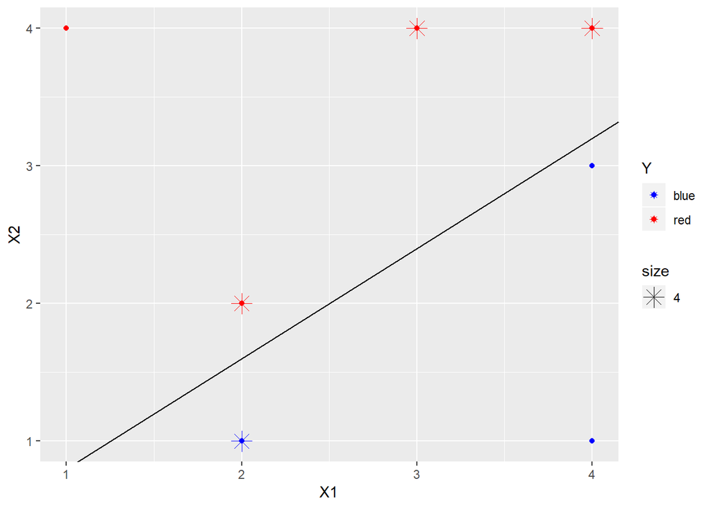

```r
  ggplot(toys, aes(X1, X2, color = Y)) + geom_point() +
  scale_color_manual(values = c("blue", "red")) +
  geom_abline(intercept = 0, slope = 0.8) +
  geom_point(data = supports, aes(x = X1, y =  X2, size = 4), shape = 8)
```

*3g* This hyperplane with the equation
$$0.8*X_{1} - X_{2} > 0$$
separates the observations correctly, but does not maximize the distance in between them.

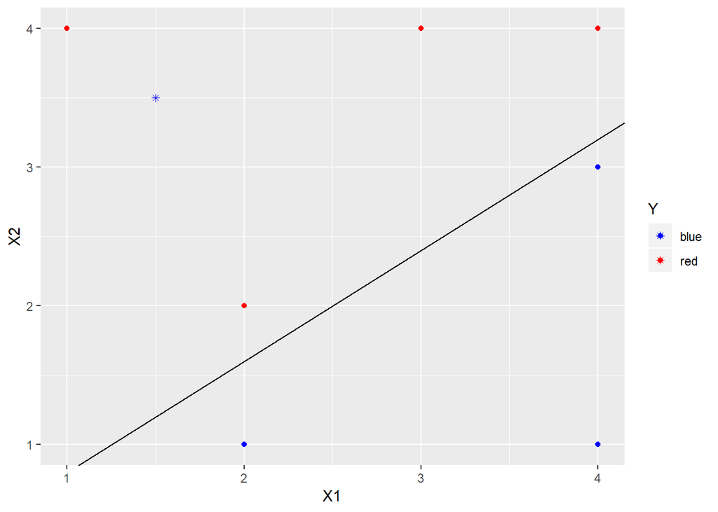

```r
  ggplot(toys, aes(X1, X2, color = Y)) + geom_point() +
  scale_color_manual(values = c("blue", "red")) +
  geom_abline(intercept = 0, slope = 0.8) +
  geom_point(data = data.frame("X1" = 1.5, "X2" = 3.5, Y = "blue"), shape = 8)
```

*3h.* As shown in the plot, the new, blue point designated with a star prevents the feature space from being separated perfectly with a hyperplane.

```r
#7a
library(dplyr)
library(ISLR)
library(e1071)
med_auto <- median(Auto$mpg)
auto_mpg <- Auto %>% mutate(gas_mileage = ifelse(Auto$mpg > med_auto, 1, 0))

#7b
set.seed(1)
tune.out = tune(svm, as.factor(gas_mileage) ~ ., data = auto_mpg, kernel = "linear", ranges = list(cost = c(0.001, 0.01, 0.1, 1, 5, 10, 100)))
summary(tune.out)
```

```
##
## Parameter tuning of 'svm':
##
## - sampling method: 10-fold cross validation
##
## - best parameters:
##  cost
##     1
##
## - best performance: 0.01275641
##
## - Detailed performance results:
##    cost      error dispersion
## 1 1e-03 0.09442308 0.03837365
## 2 1e-02 0.07403846 0.05471525
## 3 1e-01 0.03826923 0.05148114
## 4 1e+00 0.01275641 0.01344780
## 5 5e+00 0.01782051 0.01229997
## 6 1e+01 0.02038462 0.01074682
## 7 1e+02 0.03820513 0.01773427
```

*7b.* The best value of cost by cross-validation is 1.

```r
#7c
set.seed(1)
tune.out.radial <- tune(svm, as.factor(gas_mileage) ~ ., data = auto_mpg, kernel = "radial", ranges = list(cost = c(0.01, 0.1, 1, 5, 10, 100), gamma = c(0.01, 0.1, 1, 5, 10, 100)))
summary(tune.out.radial)
```

```
##
## Parameter tuning of 'svm':
##
## - sampling method: 10-fold cross validation
##
## - best parameters:
##  cost gamma
##   100  0.01
##
## - best performance: 0.01532051
##
## - Detailed performance results:
##     cost gamma      error dispersion
## 1  1e-02 1e-02 0.56115385 0.04344202
## 2  1e-01 1e-02 0.09185897 0.03862507
```

[output cut: 34 more lines]

```r
#7c cont.
tune.out.poly <- tune(svm, as.factor(gas_mileage) ~ ., data = auto_mpg, kernel = "polynomial", ranges = list(cost = c(0.01, 0.1, 1, 5, 10, 100), degree = c(2,3,4, 5)))
summary(tune.out.poly)
```

```
##
## Parameter tuning of 'svm':
##
## - sampling method: 10-fold cross validation
##
## - best parameters:
##  cost degree
##   100      2
##
## - best performance: 0.3011538
##
## - Detailed performance results:
##     cost degree     error dispersion
## 1  1e-02      2 0.5587179 0.05068311
## 2  1e-01      2 0.5587179 0.05068311
## 3  1e+00      2 0.5587179 0.05068311
## 4  5e+00      2 0.5587179 0.05068311
## 5  1e+01      2 0.5228205 0.09271988
## 6  1e+02      2 0.3011538 0.09292528
## 7  1e-02      3 0.5587179 0.05068311
## 8  1e-01      3 0.5587179 0.05068311
## 9  1e+00      3 0.5587179 0.05068311
## 10 5e+00      3 0.5587179 0.05068311
## 11 1e+01      3 0.5587179 0.05068311
## 12 1e+02      3 0.3344872 0.11043053
## 13 1e-02      4 0.5587179 0.05068311
## 14 1e-01      4 0.5587179 0.05068311
## 15 1e+00      4 0.5587179 0.05068311
## 16 5e+00      4 0.5587179 0.05068311
## 17 1e+01      4 0.5587179 0.05068311
## 18 1e+02      4 0.5587179 0.05068311
## 19 1e-02      5 0.5587179 0.05068311
## 20 1e-01      5 0.5587179 0.05068311
## 21 1e+00      5 0.5587179 0.05068311
## 22 5e+00      5 0.5587179 0.05068311
## 23 1e+01      5 0.5587179 0.05068311
## 24 1e+02      5 0.5587179 0.05068311
```

*7c.* For the radial svm model, a cost of 100 and a gamma value of 0.01 were determined to be the best by cross-validation. Cross-validation determined a cost of 100 and a degree of 2 for the polynomial svm model.

*7d.* The plots below show that the SVM with a linear kernel actually performs the best, followed by the radial kernel. The polynomial kernel SVM performs very badly.

```r
#7d

tune.out = svm(as.factor(gas_mileage) ~ ., data = auto_mpg, kernel = "linear", cost = 1)
tune.out.radial <- svm(as.factor(gas_mileage) ~ ., data = auto_mpg, kernel = "radial",cost = 100, gamma =0.01)
tune.out.poly <- svm(as.factor(gas_mileage) ~ ., data = auto_mpg, kernel = "polynomial", cost = 100, degree = 2)
names(auto_mpg)
```

```
##  [1] "mpg"          "cylinders"    "displacement" "horsepower"
##  [5] "weight"       "acceleration" "year"         "origin"
##  [9] "name"         "gas_mileage"
```

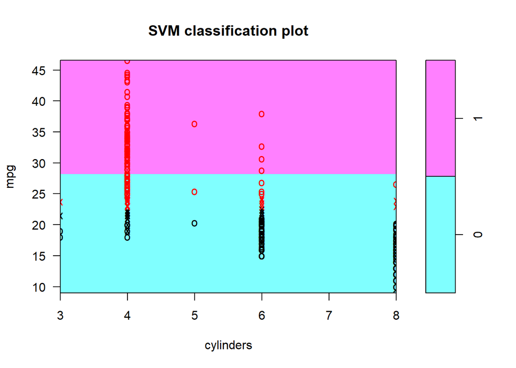

```r
# linear plots
plot(tune.out, auto_mpg, mpg~cylinders)
```

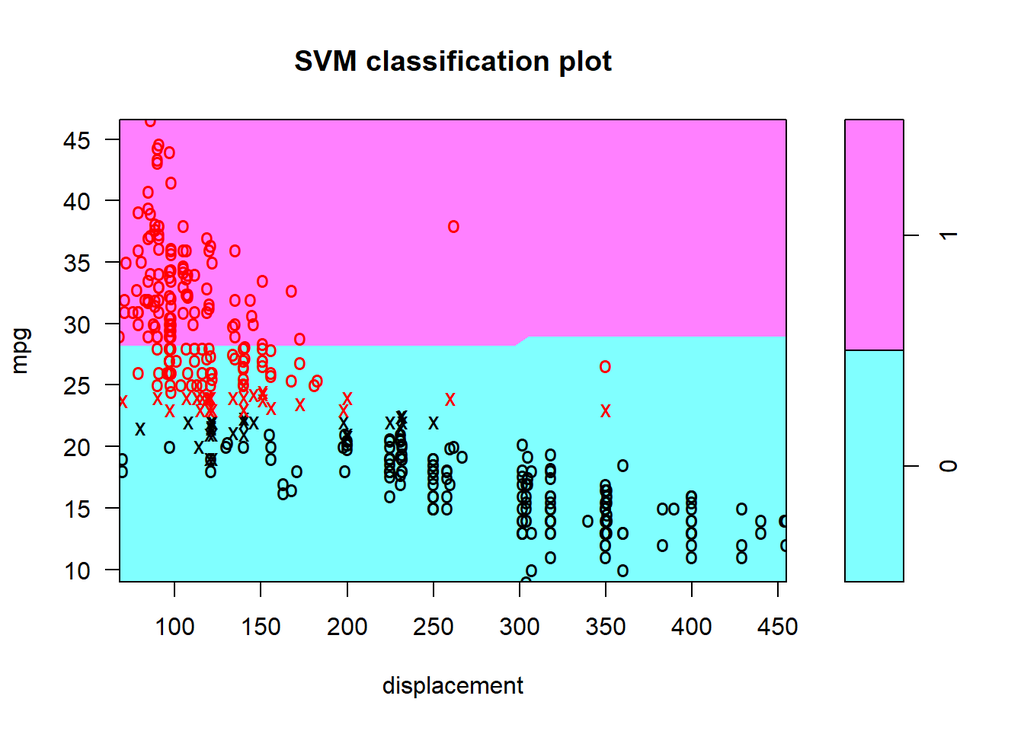

```r
plot(tune.out, auto_mpg, mpg~displacement)
```

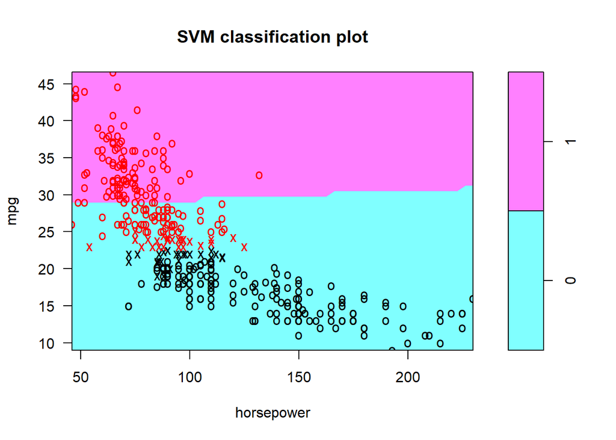

```r
plot(tune.out, auto_mpg, mpg~horsepower)
```

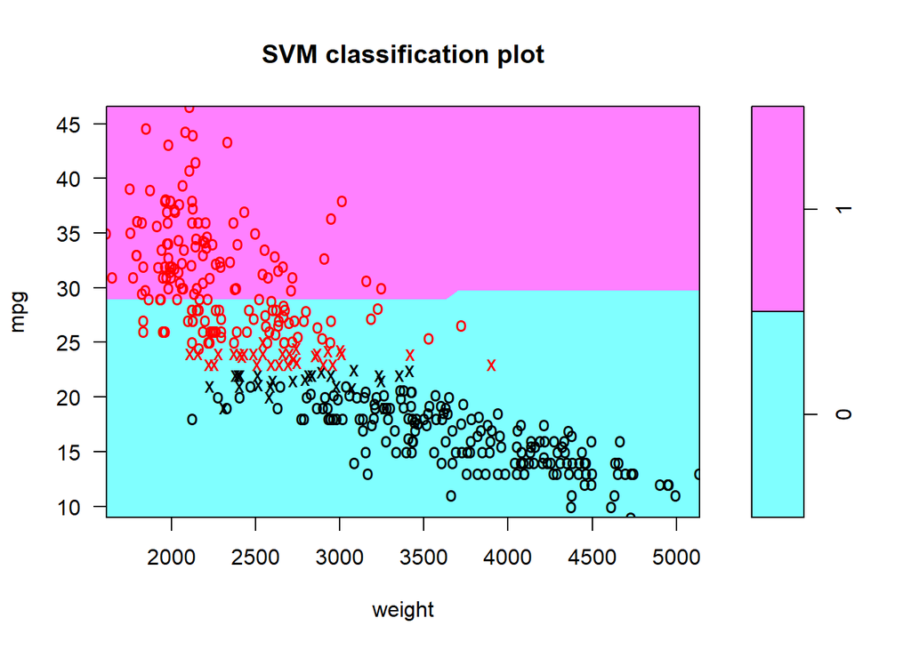

```r
plot(tune.out, auto_mpg, mpg~weight)
```

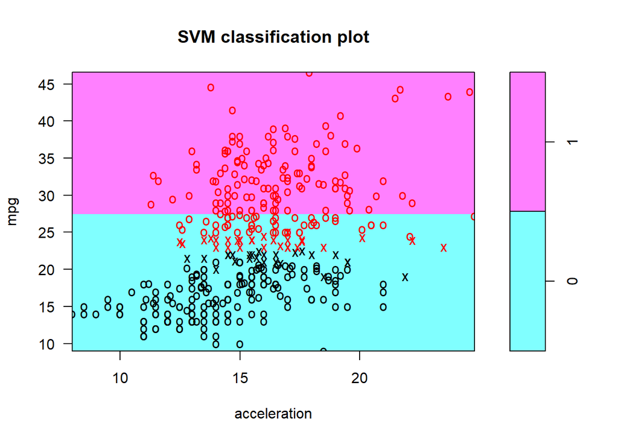

```r
plot(tune.out, auto_mpg, mpg~acceleration)
```

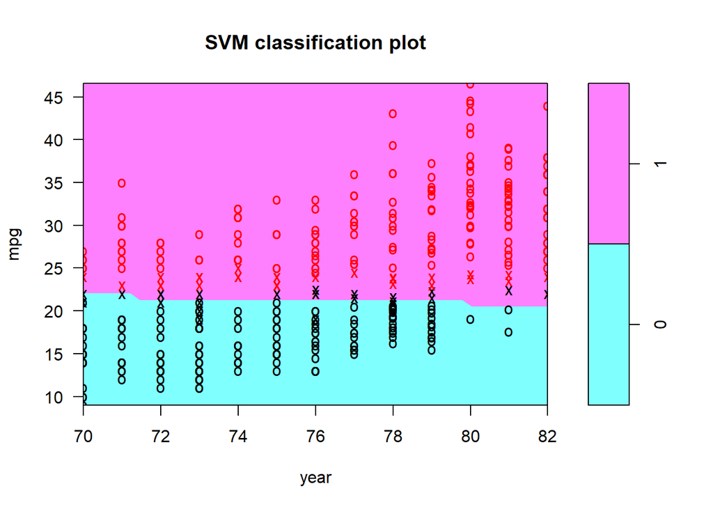

```r
plot(tune.out, auto_mpg, mpg~year)
```

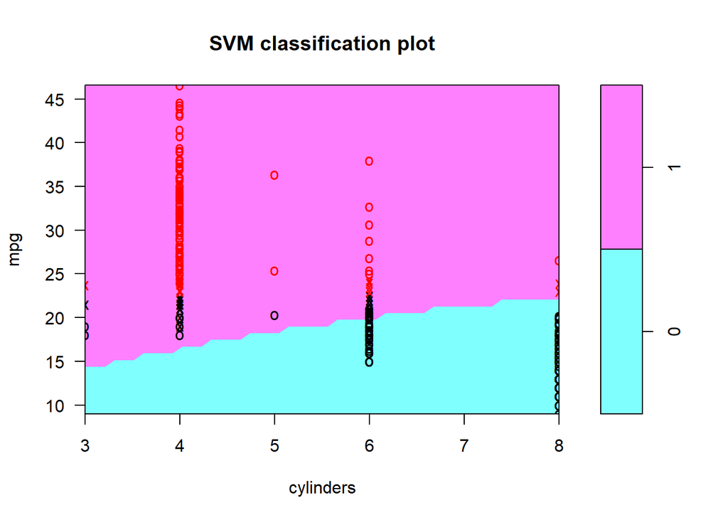

```r
# radial plots
plot(tune.out.radial, auto_mpg, mpg~cylinders)
```

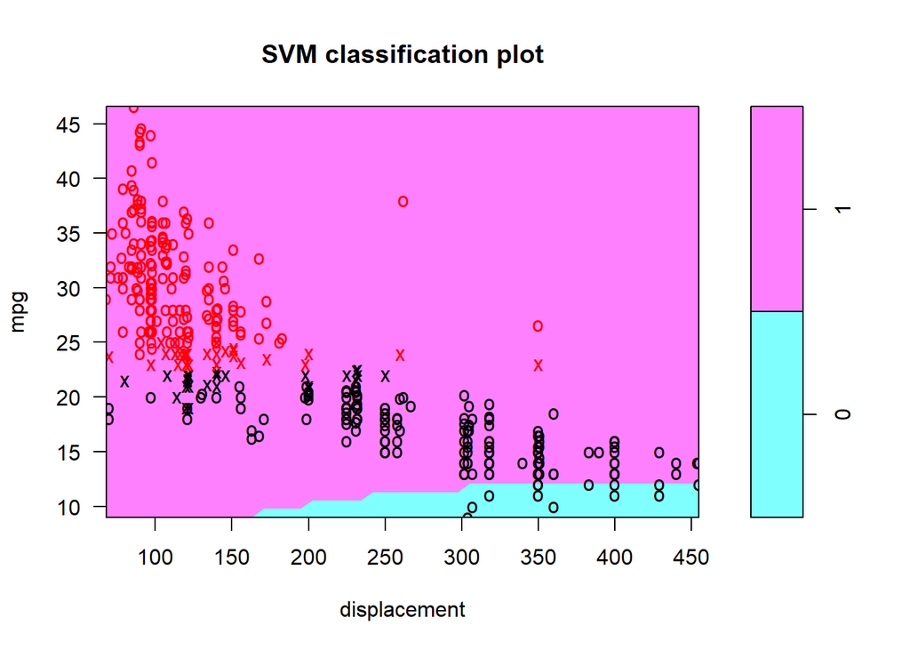

```r
plot(tune.out.radial, auto_mpg, mpg~displacement)
```

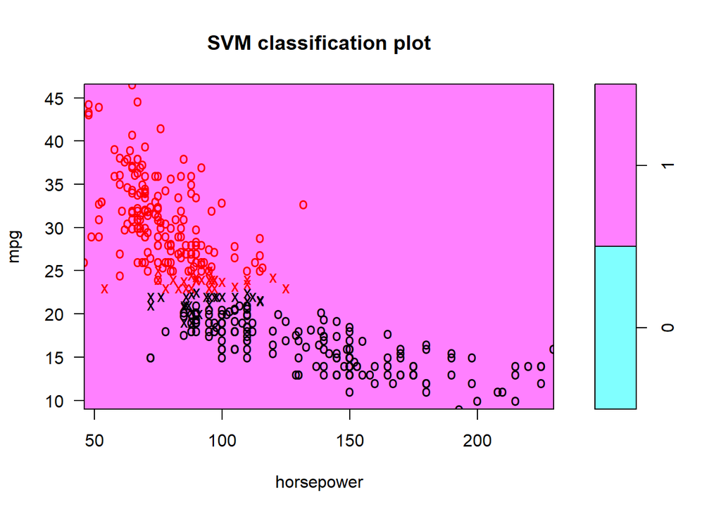

```r
plot(tune.out.radial, auto_mpg, mpg~horsepower)
```

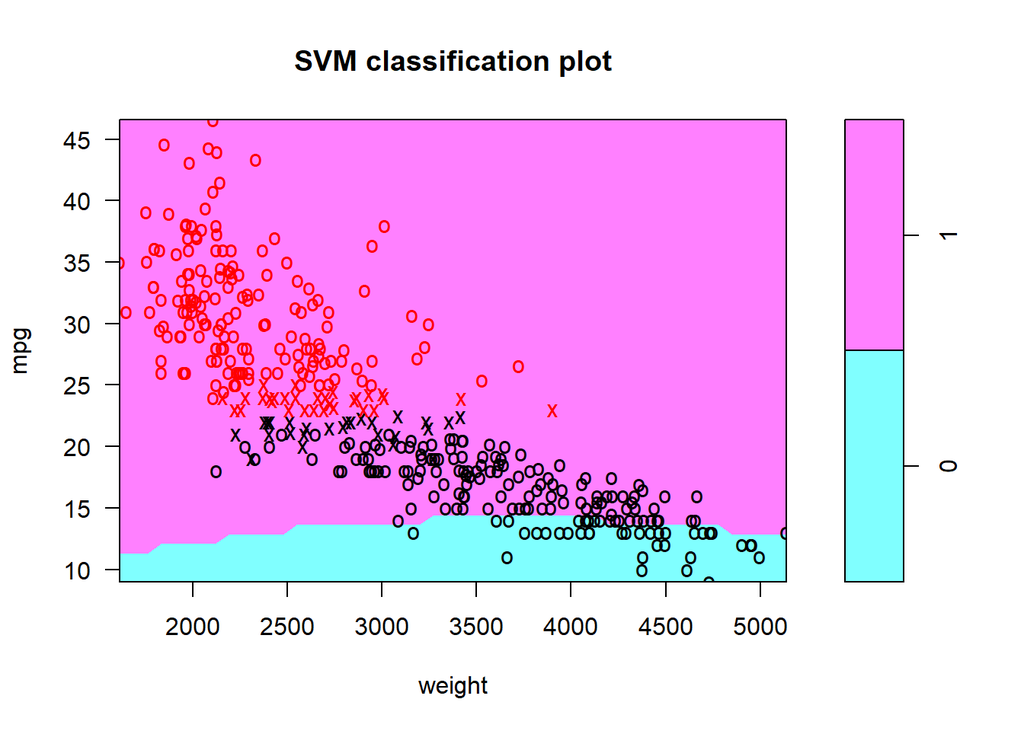

```r
plot(tune.out.radial, auto_mpg, mpg~weight)
```

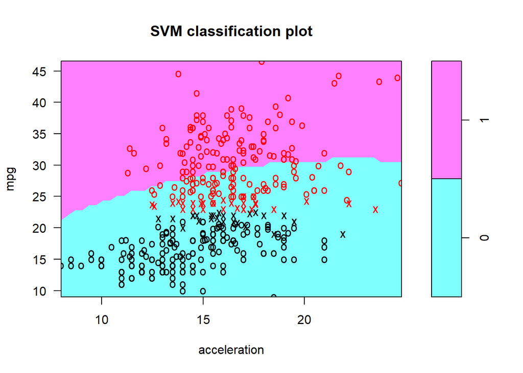

```r
plot(tune.out.radial, auto_mpg, mpg~acceleration)
```

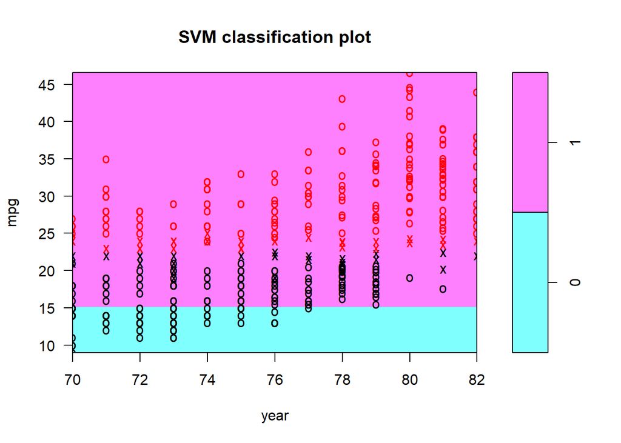

```r
plot(tune.out.radial, auto_mpg, mpg~year)
```

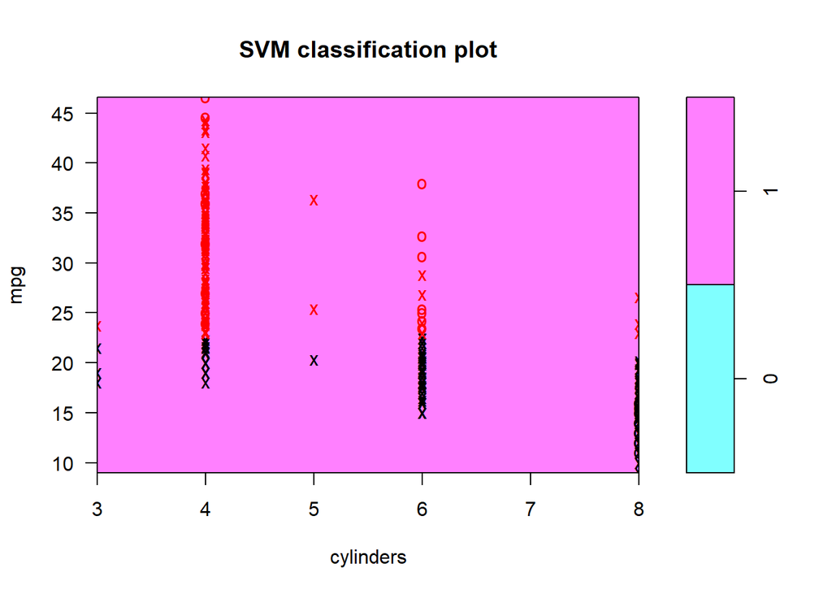

```r
#polynomial plots
plot(tune.out.poly, auto_mpg, mpg~cylinders)
```

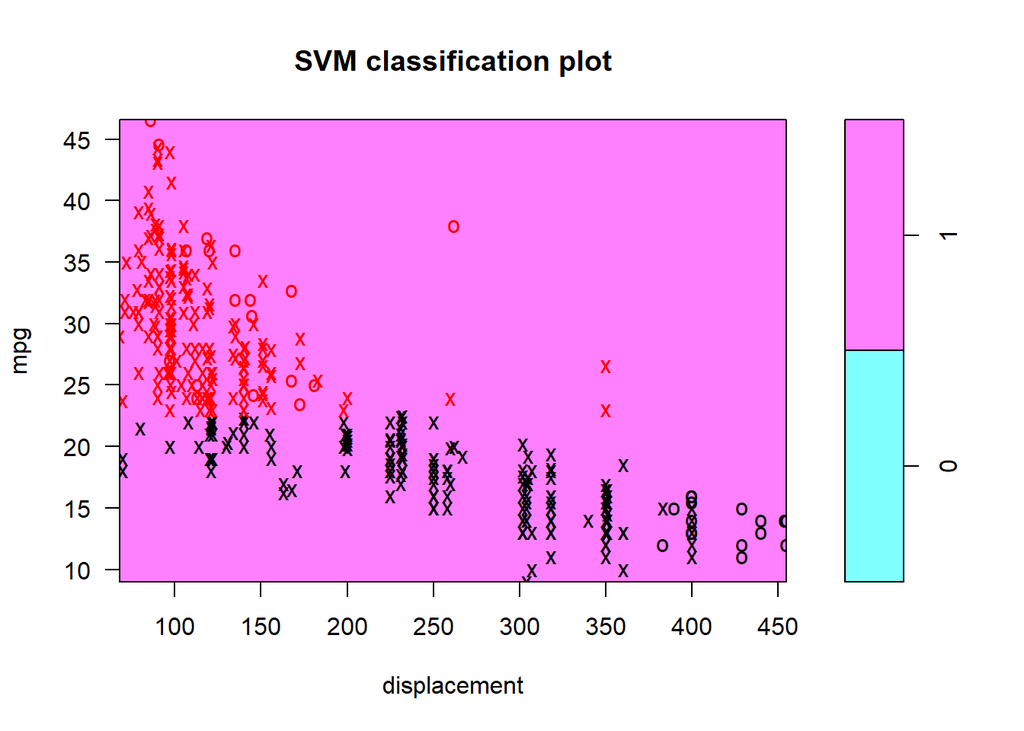

```r
plot(tune.out.poly, auto_mpg, mpg~displacement)
```

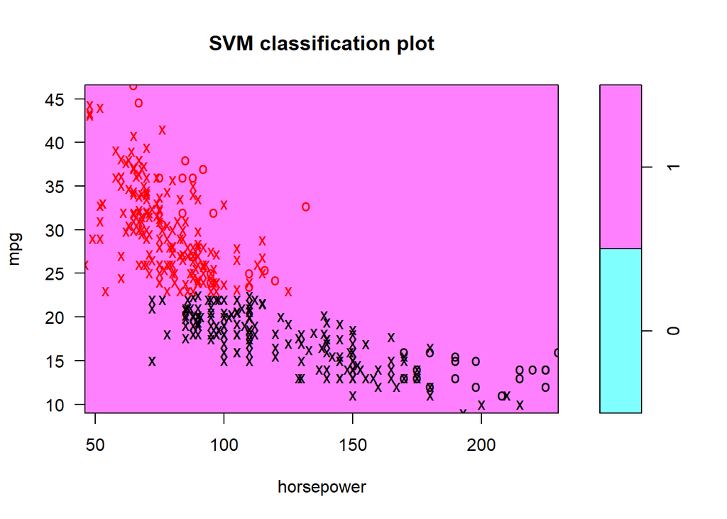

```r
plot(tune.out.poly, auto_mpg, mpg~horsepower)
```

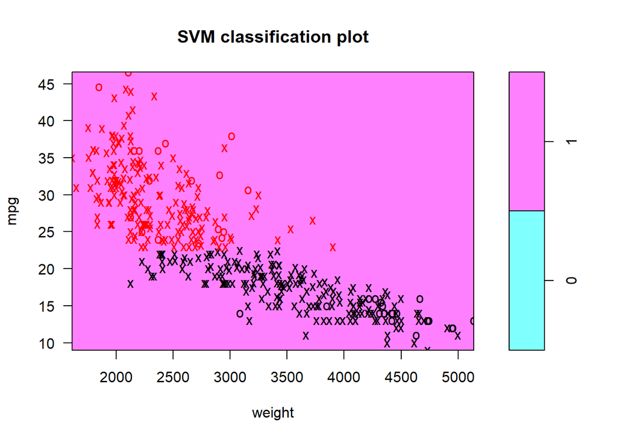

```r
plot(tune.out.poly, auto_mpg, mpg~weight)
```

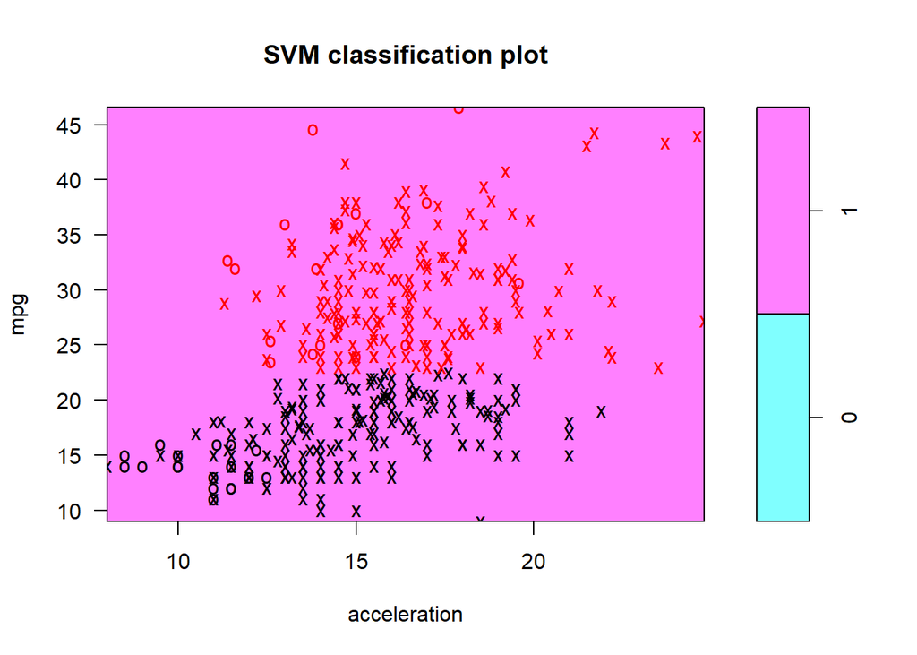

```r
plot(tune.out.poly, auto_mpg, mpg~acceleration)
```

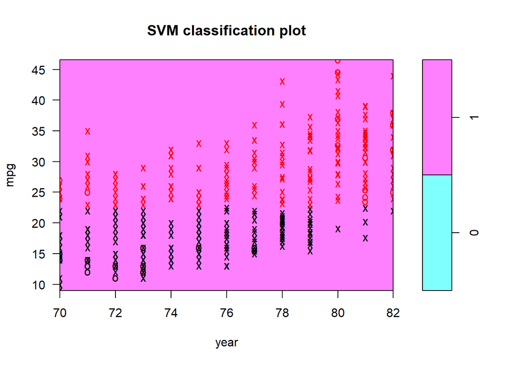

```r
plot(tune.out.poly, auto_mpg, mpg~year)
```